# Schwartzentruber_2018 QC report

Nurlan Kerimov

- PCA of gene expression data
- MDS of gene expression data
- Expression of sex-specific genes
- Assign genotyped individuals to populations
- Concordance between expression and genotype data

```
## Number of samples in study before quality control: 130
```

```
## Number of samples in study after quality control: 98
```

### PCA of gene expression data

Performs principal component analysis (PCA) of gene expression data

- Applies transcripts per million (TPM) normalisation
- Genes with median expression below 1 TPM are filtered out
- log2(matrix + 0.1) is applied

```
## Number of genes with [median(tpm) > 1]: 15677
```

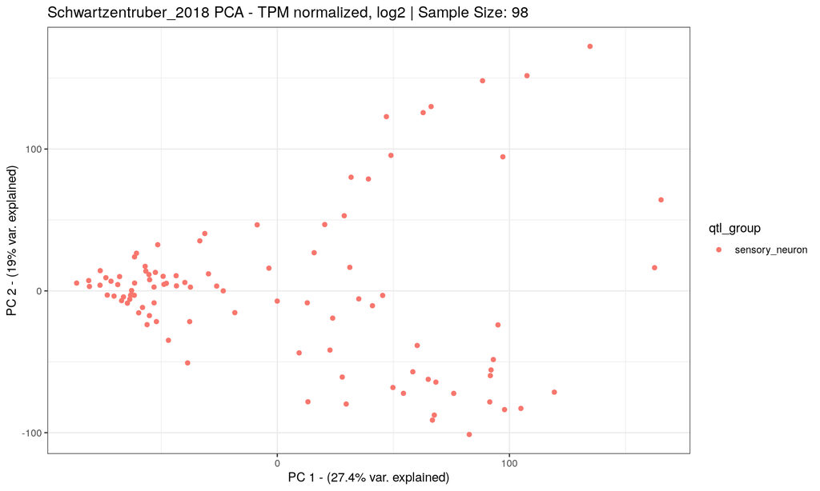

### MDS of gene expression data

Performs Multi-dimensional scaling (MDS) of gene expression data using isoMDS() R function.

- Applies transcripts per million (TPM) normalisation
- Genes with median expression below 1 TPM are filtered out
- log2(matrix + 0.1) is applied
- dist = cor(matrix, method = “pearson”)
- Data are scaled to k = 2 dimensions with isoMDS(1-dist, k=2)

```
## Number of genes with [median(tpm) > 1]: 15677
```

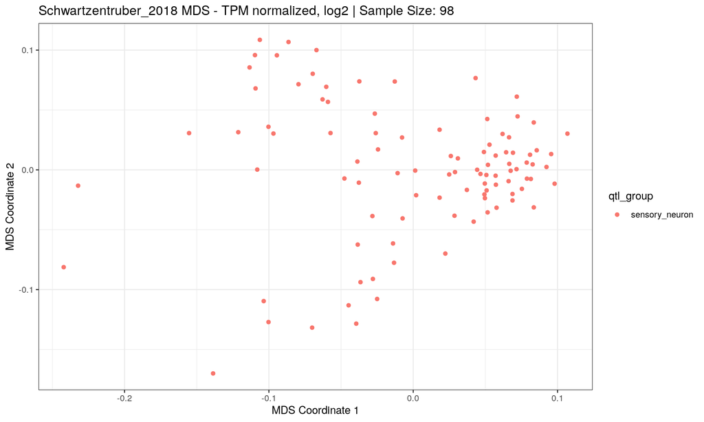

### Expression of sex-specific genes

Compares the expression of genes on the Y chromosome against the expression of XIST on the X chromosome to check if genetic sex has been correctly described in sample metadata. Inspired by the analysis peformed in [’t Hoen et al, 2013](https://doi.org/10.1038/nbt.2702).

- Values on the scatter plot are log2(tpm+1).

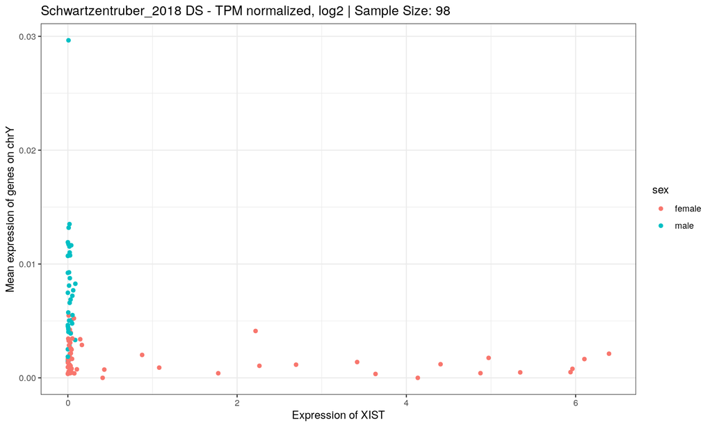

### Assign genotyped individuals to populations

Project genotyped individuals to the first two principal components of the 1000 Genomes Phase 3 reference panel.

```
## Number of genotyped individuals in the current study Schwartzentruber_2018: 98
```

```
## Number of genotyped individuals in the reference panel: 2157
```

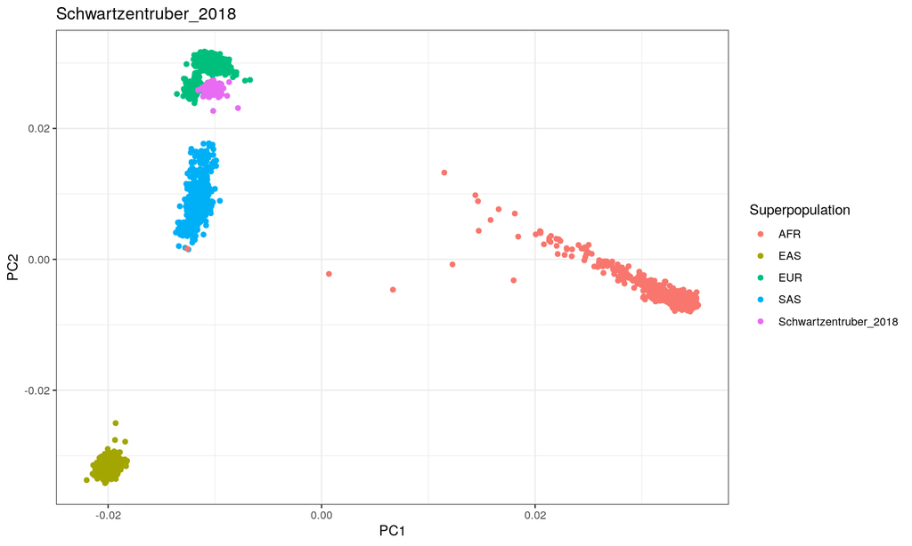

### Concordance between expression and genotype data

Uses [QTLtools mbv](https://doi.org/10.1093/bioinformatics/btx074) (Match BAM to VCF) tool to check concordance between genotype data and genetic variants detected from the RNA-seq data.

```
## Number of non-matching genotypes: 0
```

```
## Number of matching genotypes: 98
```

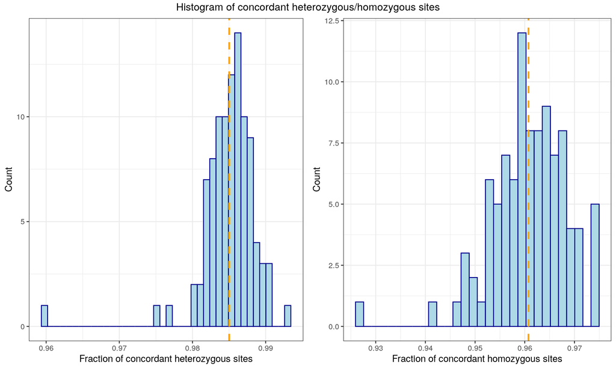

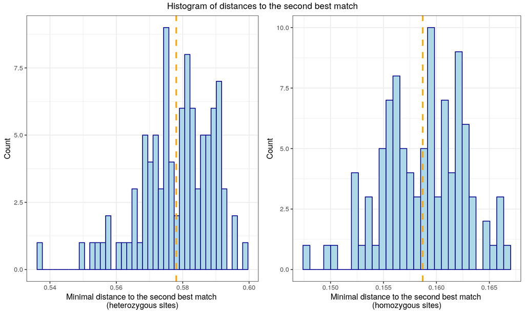